# The grammar(G) of tables(T)

## Motivation for the gt package

The gt package joins a burgeoning collection of packages for display table generation. Why another? We feel that there is enough room in this space to innovate further. Here are some of the ways that gt contributes to this ecosystem:

- the interface is high-level and declarative (general instructions versus very specific) the formatting options are ‘batteries included’ (scientific notation, uncertainty, ranges, percentages, suffixes, localized currency, dates/times + much more)
- there is excellent, pain-free support for footnotes
- the output is ‘camera-ready’
- it will eventually support multiple output formats (including LaTeX) with the same declarative interface the API closely follows tidyverse conventions by adhering to the tidyverse style guide a focus on making the package documentation and examples the best they can be rigorous
- QA/QC measures: high test coverage for automated tests, and thorough manual testing by QA engineers (with every proposed code change)

Source - https://gt.rstudio.com/.

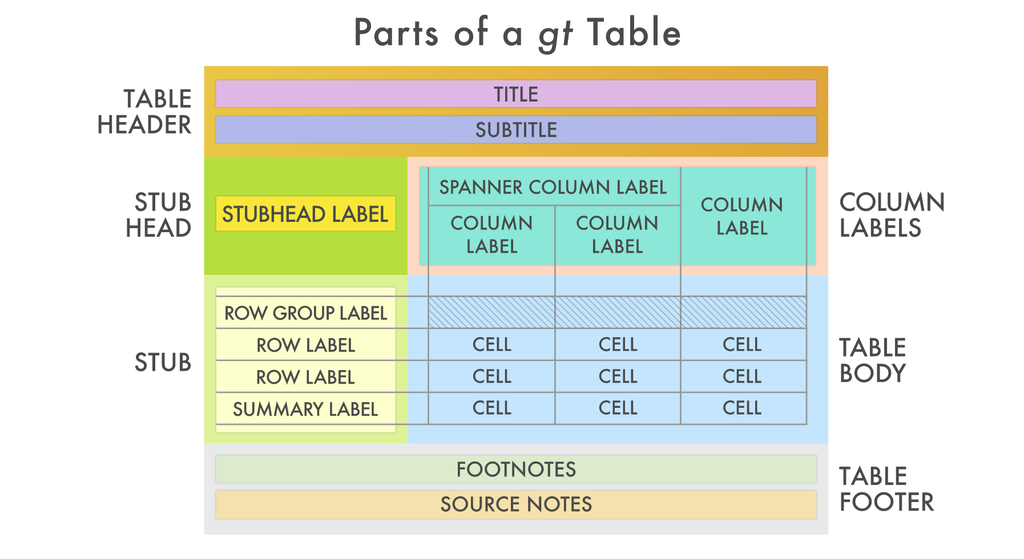

The structure

knitr — kableExtra — formattable — DT — pander — huxtable— reactable — flextable — ftextra — pixiedust — tangram — ztable — condformat — stargazer — xtable

The parts (roughly from top to bottom) are:

- the Table Header (optional; with a title and possibly a subtitle)
- the Stub and the Stub Head (optional; contains row labels, optionally within row groups having row group labels and possibly summary labels when a summary is present)
- the Column Labels (contains column labels, optionally under spanner column labels)
- the Table Body (contains columns and rows of cells)
- the Table Footer (optional; possibly with footnotes and source notes)

## Loading libraries

```r
library(plyr)
library(dplyr)
library(gt)
library(paletteer)
library(countrycode)
library(purrr)
library(tidyr)
library(ggplot2)
library(ggthemes)
```

## Reading & Preprocessing data

There are six data sets included in gt: country pops, sza, gtcars, sp500, pizzaplace, and exibble. All of them are useful for experimenting with gt’s functions.

Let’s make a display table using the gtcars data set. We all know mtcars… what is gtcars? It’s basically a modernized mtcars for the gt age. It’s part of the gt package, and here is a preview of the tibble:

```r
dplyr::glimpse(gtcars)
```

```
## Rows: 47
## Columns: 15
## $ mfr         <chr> "Ford", "Ferrari", "Ferrari", "Ferrari", "Ferrari", "Ferr…
## $ model       <chr> "GT", "458 Speciale", "458 Spider", "458 Italia", "488 GT…
## $ year        <dbl> 2017, 2015, 2015, 2014, 2016, 2015, 2017, 2015, 2015, 201…
## $ trim        <chr> "Base Coupe", "Base Coupe", "Base", "Base Coupe", "Base C…
## $ bdy_style   <chr> "coupe", "coupe", "convertible", "coupe", "coupe", "conve…
## $ hp          <dbl> 647, 597, 562, 562, 661, 553, 680, 652, 731, 949, 573, 54…
## $ hp_rpm      <dbl> 6250, 9000, 9000, 9000, 8000, 7500, 8250, 8000, 8250, 900…
## $ trq         <dbl> 550, 398, 398, 398, 561, 557, 514, 504, 509, 664, 476, 43…
## $ trq_rpm     <dbl> 5900, 6000, 6000, 6000, 3000, 4750, 5750, 6000, 6000, 675…
## $ mpg_c       <dbl> 11, 13, 13, 13, 15, 16, 12, 11, 11, 12, 21, 16, 11, 16, 1…
## $ mpg_h       <dbl> 18, 17, 17, 17, 22, 23, 17, 16, 16, 16, 22, 22, 18, 20, 2…
## $ drivetrain  <chr> "rwd", "rwd", "rwd", "rwd", "rwd", "rwd", "awd", "awd", "…
## $ trsmn       <chr> "7a", "7a", "7a", "7a", "7a", "7a", "7a", "7a", "7a", "7a…
## $ ctry_origin <chr> "United States", "Italy", "Italy", "Italy", "Italy", "Ita…
## $ msrp        <dbl> 447000, 291744, 263553, 233509, 245400, 198973, 298000, 2…
```

Filtering for a single year and including only top manufacturers

```r
gtcars_sub = gtcars %>%
    filter(year == 2016 & mfr %in% c("Aston Martin", "Audi", "Mercedes-Benz", "Maserati", "BMW"))%>%
    select(-year) %>%
    group_by(model,mfr,bdy_style,trsmn) %>%
    summarise_if(is.numeric, sum, na.rm = TRUE) %>%
    dplyr::arrange(desc(msrp)) %>%
    data.frame()

list = unique(gtcars_sub$mfr)

df = data.frame()

for (i in unique(gtcars_sub$mfr)){
  a = gtcars_sub %>% filter(mfr == i) %>% arrange(msrp,hp) %>% head(2)
  df = rbind(a, df)
}

gtcars_sub$mfr = as.factor(gtcars_sub$mfr)
```

## Creating a basic GT table

Creating a basic gt table with manufacturers arranged into row groups. As seen, the name of the selected manufacturers is displayed prominently above

```r
 tab =  df %>%
  gt(rowname_col = "row", groupname_col = "mfr")

tab
```

| model | bdy_style | trsmn | hp | hp_rpm | trq | trq_rpm | mpg_c | mpg_h | msrp |
| --- | --- | --- | --- | --- | --- | --- | --- | --- | --- |
| Audi |  |  |  |  |  |  |  |  |  |
| S6 | sedan | 7a | 450 | 5800 | 406 | 1400 | 18 | 27 | 70900 |
| S7 | hatchback | 7a | 450 | 5800 | 406 | 1400 | 17 | 27 | 82900 |
| Mercedes-Benz |  |  |  |  |  |  |  |  |  |
| SL-Class | convertible | 7am | 329 | 5250 | 354 | 1600 | 20 | 27 | 85050 |
| AMG GT | coupe | 7a | 503 | 6250 | 479 | 1750 | 16 | 22 | 129900 |
| Maserati |  |  |  |  |  |  |  |  |  |
| Ghibli | sedan | 8am | 345 | 5250 | 369 | 1750 | 17 | 24 | 70600 |
| Quattroporte | sedan | 8am | 404 | 5500 | 406 | 1500 | 16 | 23 | 99900 |
| BMW |  |  |  |  |  |  |  |  |  |
| M4 | coupe | 6m | 425 | 5500 | 406 | 1850 | 17 | 24 | 65700 |
| 6-Series | coupe | 8am | 315 | 5800 | 330 | 1400 | 20 | 30 | 77300 |
| Aston Martin |  |  |  |  |  |  |  |  |  |
| Vantage | coupe | 6m | 430 | 7300 | 361 | 5000 | 13 | 19 | 103300 |
| Rapide S | sedan | 8am | 552 | 6650 | 465 | 5500 | 14 | 21 | 205300 |

## Adding Flags for Country origin

Adding the home country flag of each manufacturer. A separate data frame is first created with each manufacturer and the corresponding flag. This is then joined to the earlier data frame by a unique manufacturer key and the table is finally remade.

```r
Countries <- c('United Kingdom', 'Germany', 'Germany', 'Germany', 'Italy')
Flags <- countrycode(Countries, 'country.name', 'unicode.symbol')
mfr = c("Aston Martin", "BMW", "Mercedes-Benz", "Audi", "Maserati")
mfr_flag = data.frame()
mfr_flag = data_frame(mfr, Flags) %>% data.frame()
glimpse(mfr_flag)
```

```
## Rows: 5
## Columns: 2
## $ mfr   <chr> "Aston Martin", "BMW", "Mercedes-Benz", "Audi", "Maserati"
## $ Flags <chr> "\U0001f1ec\U0001f1e7", "\U0001f1e9\U0001f1ea", "\U0001f1e9\U00…
```

```r
df = join(df, mfr_flag, by = "mfr")
df = df %>% mutate(mfr = paste(mfr, Flags))
df$Flags = NULL


tab =  df %>%
  gt(rowname_col = "row", groupname_col = "mfr")

tab
```

| model | bdy_style | trsmn | hp | hp_rpm | trq | trq_rpm | mpg_c | mpg_h | msrp |
| --- | --- | --- | --- | --- | --- | --- | --- | --- | --- |
| Audi 🇩🇪 |  |  |  |  |  |  |  |  |  |
| S6 | sedan | 7a | 450 | 5800 | 406 | 1400 | 18 | 27 | 70900 |
| S7 | hatchback | 7a | 450 | 5800 | 406 | 1400 | 17 | 27 | 82900 |
| Mercedes-Benz 🇩🇪 |  |  |  |  |  |  |  |  |  |
| SL-Class | convertible | 7am | 329 | 5250 | 354 | 1600 | 20 | 27 | 85050 |
| AMG GT | coupe | 7a | 503 | 6250 | 479 | 1750 | 16 | 22 | 129900 |
| Maserati 🇮🇹 |  |  |  |  |  |  |  |  |  |
| Ghibli | sedan | 8am | 345 | 5250 | 369 | 1750 | 17 | 24 | 70600 |
| Quattroporte | sedan | 8am | 404 | 5500 | 406 | 1500 | 16 | 23 | 99900 |
| BMW 🇩🇪 |  |  |  |  |  |  |  |  |  |
| M4 | coupe | 6m | 425 | 5500 | 406 | 1850 | 17 | 24 | 65700 |
| 6-Series | coupe | 8am | 315 | 5800 | 330 | 1400 | 20 | 30 | 77300 |
| Aston Martin 🇬🇧 |  |  |  |  |  |  |  |  |  |
| Vantage | coupe | 6m | 430 | 7300 | 361 | 5000 | 13 | 19 | 103300 |
| Rapide S | sedan | 8am | 552 | 6650 | 465 | 5500 | 14 | 21 | 205300 |

## Spanning, Merging & changing column names

Occasionally we’d like to combine the data from two columns into a single column. The cols_merge() function lets us to do this, we just need to detail how the data should be combined. For our table, let’s merge together the following pairs of columns:

- mpg_c and mpg_h (miles per gallon in city and highway driving modes)
- hp and hp_rpm (horsepower and associated RPM)
- trq and trq_rpm (torque and associated RPM)

```r
 tab= tab %>%
   tab_spanner(
    label = "Performance",
    columns = vars(mpg_c, mpg_h, hp, hp_rpm, trq, trq_rpm)
  )%>%
  cols_merge(
    vars(mpg_c, mpg_h),
    hide_columns = vars(mpg_h),
    pattern = "{1}c<br>{2}h"
    ) %>%
  cols_merge(
    vars(hp, hp_rpm),
    hide_columns = vars(hp_rpm),
    pattern = "{1}<br>@{2}rpm"
  ) %>%
  cols_merge(
    vars(trq, trq_rpm),
    hide_columns = vars(trq_rpm),
    pattern = "{1}<br>@{2}rpm"
  ) %>%
  cols_label(
    mpg_c = "MPG",
    hp = "HP",
    trq = "Torque",
    trsmn = "Transmission",
    msrp = "MSRP",
    bdy_style = "Body Style",
    model = "Model"
  )
tab
```

| Model | Body Style | Transmission | Performance MPG | Performance HP | Performance Torque | MSRP |  |
| --- | --- | --- | --- | --- | --- | --- | --- |
| Audi 🇩🇪 |  |  |  |  |  |  |  |
| S6 | sedan | 7a | 18c 27h | 450 @5800rpm | 406 @1400rpm |  | 70900 |
| S7 | hatchback | 7a | 17c 27h | 450 @5800rpm | 406 @1400rpm | 82900 |  |
| Mercedes-Benz 🇩🇪 |  |  |  |  |  |  |  |
| SL-Class | convertible | 7am | 20c 27h | 329 @5250rpm | 354 @1600rpm | 85050 |  |
| AMG GT | coupe | 7a | 16c 22h | 503 @6250rpm | 479 @1750rpm | 129900 |  |
| Maserati 🇮🇹 |  |  |  |  |  |  |  |
| Ghibli | sedan | 8am | 17c 24h | 345 @5250rpm | 369 @1750rpm | 70600 |  |
| Quattroporte | sedan | 8am | 16c 23h | 404 @5500rpm | 406 @1500rpm | 99900 |  |
| BMW 🇩🇪 |  |  |  |  |  |  |  |
| M4 | coupe | 6m | 17c 24h | 425 @5500rpm | 406 @1850rpm | 65700 |  |
| 6-Series | coupe | 8am | 20c 30h | 315 @5800rpm | 330 @1400rpm | 77300 |  |
| Aston Martin 🇬🇧 |  |  |  |  |  |  |  |
| Vantage | coupe | 6m | 13c 19h | 430 @7300rpm | 361 @5000rpm | 103300 |  |
| Rapide S | sedan | 8am | 14c 21h | 552 @6650rpm | 465 @5500rpm | 205300 |  |

## Formatting units

There are a number of formatter() functions, thankfully all share the general naming convention fmt*(). The various formatters are convenient for applying formats to numeric or character values in the table’s field. Here, we will simply use fmt_currency() on the msrp column (we still refer to columns by their original names) to get USD currency will no decimal places. We’re not supplying anything for the rows argument and this means we want to apply the formatting to the entire column of data.

```r
 tab = tab %>%
  fmt_currency(
    columns = vars(msrp),
    currency = "USD",
    decimals = 0
  )
tab
```

| Model | Body Style | Transmission | Performance MPG | Performance HP | Performance Torque | MSRP |  |
| --- | --- | --- | --- | --- | --- | --- | --- |
| Audi 🇩🇪 |  |  |  |  |  |  |  |
| S6 | sedan | 7a | 18c 27h | 450 @5800rpm | 406 @1400rpm |  | $70,900 |
| S7 | hatchback | 7a | 17c 27h | 450 @5800rpm | 406 @1400rpm | $82,900 |  |
| Mercedes-Benz 🇩🇪 |  |  |  |  |  |  |  |
| SL-Class | convertible | 7am | 20c 27h | 329 @5250rpm | 354 @1600rpm | $85,050 |  |
| AMG GT | coupe | 7a | 16c 22h | 503 @6250rpm | 479 @1750rpm | $129,900 |  |
| Maserati 🇮🇹 |  |  |  |  |  |  |  |
| Ghibli | sedan | 8am | 17c 24h | 345 @5250rpm | 369 @1750rpm | $70,600 |  |
| Quattroporte | sedan | 8am | 16c 23h | 404 @5500rpm | 406 @1500rpm | $99,900 |  |
| BMW 🇩🇪 |  |  |  |  |  |  |  |
| M4 | coupe | 6m | 17c 24h | 425 @5500rpm | 406 @1850rpm | $65,700 |  |
| 6-Series | coupe | 8am | 20c 30h | 315 @5800rpm | 330 @1400rpm | $77,300 |  |
| Aston Martin 🇬🇧 |  |  |  |  |  |  |  |
| Vantage | coupe | 6m | 13c 19h | 430 @7300rpm | 361 @5000rpm | $103,300 |  |
| Rapide S | sedan | 8am | 14c 21h | 552 @6650rpm | 465 @5500rpm | $205,300 |  |

## Column Alignment and Style Changes

```r
tab <-
  tab %>%
  cols_align(
    align = "center",
    columns = vars(mpg_c, hp, trq)
  ) %>%
  tab_style(
    style = cell_text(size = px(12)),
    locations = cells_body(
      columns = vars( trsmn, mpg_c, hp, trq))
  )
tab
```

| Model | Body Style | Transmission | Performance MPG | Performance HP | Performance Torque | MSRP |  |
| --- | --- | --- | --- | --- | --- | --- | --- |
| Audi 🇩🇪 |  |  |  |  |  |  |  |
| S6 | sedan | 7a | 18c 27h | 450 @5800rpm | 406 @1400rpm |  | $70,900 |
| S7 | hatchback | 7a | 17c 27h | 450 @5800rpm | 406 @1400rpm | $82,900 |  |
| Mercedes-Benz 🇩🇪 |  |  |  |  |  |  |  |
| SL-Class | convertible | 7am | 20c 27h | 329 @5250rpm | 354 @1600rpm | $85,050 |  |
| AMG GT | coupe | 7a | 16c 22h | 503 @6250rpm | 479 @1750rpm | $129,900 |  |
| Maserati 🇮🇹 |  |  |  |  |  |  |  |
| Ghibli | sedan | 8am | 17c 24h | 345 @5250rpm | 369 @1750rpm | $70,600 |  |
| Quattroporte | sedan | 8am | 16c 23h | 404 @5500rpm | 406 @1500rpm | $99,900 |  |
| BMW 🇩🇪 |  |  |  |  |  |  |  |
| M4 | coupe | 6m | 17c 24h | 425 @5500rpm | 406 @1850rpm | $65,700 |  |
| 6-Series | coupe | 8am | 20c 30h | 315 @5800rpm | 330 @1400rpm | $77,300 |  |
| Aston Martin 🇬🇧 |  |  |  |  |  |  |  |
| Vantage | coupe | 6m | 13c 19h | 430 @7300rpm | 361 @5000rpm | $103,300 |  |
| Rapide S | sedan | 8am | 14c 21h | 552 @6650rpm | 465 @5500rpm | $205,300 |  |

## Text Transformations

A text transform via the text_transform() function is a great way to further manipulate text in data cells (even after they’ve been formatted with the fmt*() function). After targeting data cells with the cells_body() location helper function, we supply a function to the fn argument that processes a vector of text. If we intend to render as an HTML table, we can directly apply HTML tags in the transformation function. The function we provide here will build strings that read better in a display table.

```r
tab <-
  tab %>%
  text_transform(
    locations = cells_body(columns = vars(trsmn)),
    fn = function(x) {

      speed <- substr(x, 1, 1)


      type <-
        dplyr::case_when(
          substr(x, 2, 3) == "am" ~ "Automatic/Manual",
          substr(x, 2, 2) == "m" ~ "Manual",
          substr(x, 2, 2) == "a" ~ "Automatic",
          substr(x, 2, 3) == "dd" ~ "Direct Drive"
        )

      paste(speed, " Speed<br><em>", type, "</em>")
    }
  )

tab
```

| Model | Body Style | Transmission | Performance MPG | Performance HP | Performance Torque | MSRP |  |
| --- | --- | --- | --- | --- | --- | --- | --- |
| Audi 🇩🇪 |  |  |  |  |  |  |  |
| S6 | sedan | 7 Speed *Automatic* | 18c 27h | 450 @5800rpm | 406 @1400rpm |  | $70,900 |
| S7 | hatchback | 7 Speed *Automatic* | 17c 27h | 450 @5800rpm | 406 @1400rpm | $82,900 |  |
| Mercedes-Benz 🇩🇪 |  |  |  |  |  |  |  |
| SL-Class | convertible | 7 Speed *Automatic/Manual* | 20c 27h | 329 @5250rpm | 354 @1600rpm | $85,050 |  |
| AMG GT | coupe | 7 Speed *Automatic* | 16c 22h | 503 @6250rpm | 479 @1750rpm | $129,900 |  |
| Maserati 🇮🇹 |  |  |  |  |  |  |  |
| Ghibli | sedan | 8 Speed *Automatic/Manual* | 17c 24h | 345 @5250rpm | 369 @1750rpm | $70,600 |  |
| Quattroporte | sedan | 8 Speed *Automatic/Manual* | 16c 23h | 404 @5500rpm | 406 @1500rpm | $99,900 |  |
| BMW 🇩🇪 |  |  |  |  |  |  |  |
| M4 | coupe | 6 Speed *Manual* | 17c 24h | 425 @5500rpm | 406 @1850rpm | $65,700 |  |
| 6-Series | coupe | 8 Speed *Automatic/Manual* | 20c 30h | 315 @5800rpm | 330 @1400rpm | $77,300 |  |
| Aston Martin 🇬🇧 |  |  |  |  |  |  |  |
| Vantage | coupe | 6 Speed *Manual* | 13c 19h | 430 @7300rpm | 361 @5000rpm | $103,300 |  |
| Rapide S | sedan | 8 Speed *Automatic/Manual* | 14c 21h | 552 @6650rpm | 465 @5500rpm | $205,300 |  |

## Adding Title and Subtitle

We can add a table header to the gt table with a title and even a subtitle. A table header is an optional table part that is positioned above the column labels. We have the flexibility to use Markdown formatting for the header’s title and subtitle. Furthermore, if the table is intended for HTML output, we can use HTML in either of the title or subtitle.

```r
tab <-
  tab %>%
  tab_header(
    title = md(paste0( "The Cars of **gtcars**" )),
    subtitle = "These are some fine automobiles"
  )
# Show the table
tab
```

The Cars of **gtcars**

These are some fine automobiles

| Model | Body Style | Transmission | Performance MPG | Performance HP | Performance Torque | MSRP |  |
| --- | --- | --- | --- | --- | --- | --- | --- |
| Audi 🇩🇪 |  |  |  |  |  |  |  |
| S6 | sedan | 7 Speed *Automatic* | 18c 27h | 450 @5800rpm | 406 @1400rpm |  | $70,900 |
| S7 | hatchback | 7 Speed *Automatic* | 17c 27h | 450 @5800rpm | 406 @1400rpm | $82,900 |  |
| Mercedes-Benz 🇩🇪 |  |  |  |  |  |  |  |
| SL-Class | convertible | 7 Speed *Automatic/Manual* | 20c 27h | 329 @5250rpm | 354 @1600rpm | $85,050 |  |
| AMG GT | coupe | 7 Speed *Automatic* | 16c 22h | 503 @6250rpm | 479 @1750rpm | $129,900 |  |
| Maserati 🇮🇹 |  |  |  |  |  |  |  |
| Ghibli | sedan | 8 Speed *Automatic/Manual* | 17c 24h | 345 @5250rpm | 369 @1750rpm | $70,600 |  |
| Quattroporte | sedan | 8 Speed *Automatic/Manual* | 16c 23h | 404 @5500rpm | 406 @1500rpm | $99,900 |  |
| BMW 🇩🇪 |  |  |  |  |  |  |  |
| M4 | coupe | 6 Speed *Manual* | 17c 24h | 425 @5500rpm | 406 @1850rpm | $65,700 |  |
| 6-Series | coupe | 8 Speed *Automatic/Manual* | 20c 30h | 315 @5800rpm | 330 @1400rpm | $77,300 |  |
| Aston Martin 🇬🇧 |  |  |  |  |  |  |  |
| Vantage | coupe | 6 Speed *Manual* | 13c 19h | 430 @7300rpm | 361 @5000rpm | $103,300 |  |
| Rapide S | sedan | 8 Speed *Automatic/Manual* | 14c 21h | 552 @6650rpm | 465 @5500rpm | $205,300 |  |

## Adding Custom Column Color Scales

It’s possible to add color to data cells according to their values. The data_color() function colors all rows of any columns supplied. There are two ways to define how cells are colored: (1) through the use of a supplied color palette, and (2) through use of a color mapping function available from the scales package. The first method colorizes cell data according to whether values are character or numeric. The second method provides more control over how cells are colored since we provide an explicit color function and thus other requirements such as bin counts, cut points, or a numeric domain. Finally, we can choose whether to apply the cell-specific colors to either the cell background or the cell text.

```r
tab = tab %>%
data_color(
    columns = vars(mpg_c, mpg_h, hp, hp_rpm, trq, trq_rpm, msrp),
    colors = scales::col_numeric(
     palette = paletteer::paletteer_d(
            palette = "ggsci::amber_material"
        ) %>% as.character(),
        domain = NULL
    ))
tab
```

The Cars of **gtcars**

These are some fine automobiles

| Model | Body Style | Transmission | Performance MPG | Performance HP | Performance Torque | MSRP |  |
| --- | --- | --- | --- | --- | --- | --- | --- |
| Audi 🇩🇪 |  |  |  |  |  |  |  |
| S6 | sedan | 7 Speed *Automatic* | 18c 27h | 450 @5800rpm | 406 @1400rpm |  | $70,900 |
| S7 | hatchback | 7 Speed *Automatic* | 17c 27h | 450 @5800rpm | 406 @1400rpm | $82,900 |  |
| Mercedes-Benz 🇩🇪 |  |  |  |  |  |  |  |
| SL-Class | convertible | 7 Speed *Automatic/Manual* | 20c 27h | 329 @5250rpm | 354 @1600rpm | $85,050 |  |
| AMG GT | coupe | 7 Speed *Automatic* | 16c 22h | 503 @6250rpm | 479 @1750rpm | $129,900 |  |
| Maserati 🇮🇹 |  |  |  |  |  |  |  |
| Ghibli | sedan | 8 Speed *Automatic/Manual* | 17c 24h | 345 @5250rpm | 369 @1750rpm | $70,600 |  |
| Quattroporte | sedan | 8 Speed *Automatic/Manual* | 16c 23h | 404 @5500rpm | 406 @1500rpm | $99,900 |  |
| BMW 🇩🇪 |  |  |  |  |  |  |  |
| M4 | coupe | 6 Speed *Manual* | 17c 24h | 425 @5500rpm | 406 @1850rpm | $65,700 |  |
| 6-Series | coupe | 8 Speed *Automatic/Manual* | 20c 30h | 315 @5800rpm | 330 @1400rpm | $77,300 |  |
| Aston Martin 🇬🇧 |  |  |  |  |  |  |  |
| Vantage | coupe | 6 Speed *Manual* | 13c 19h | 430 @7300rpm | 361 @5000rpm | $103,300 |  |
| Rapide S | sedan | 8 Speed *Automatic/Manual* | 14c 21h | 552 @6650rpm | 465 @5500rpm | $205,300 |  |

## Adding borders to the table

The cell_borders() helper function is to be used with the tab_style() function, which itself allows for the setting of custom styles to one or more cells. Specifically, the call to cell_borders() should be bound to the styles argument of tab_style(). The selection argument is where we define which borders should be modified (e.g., “left”, “right”, etc.). With that selection, the color, style, and weight of the selected borders can then be modified.

```r
tab = tab %>%  tab_style(
    style = list(
      cell_borders(
        sides = "left",
        color = "black",
        weight = px(3)
      )
    ),
    locations = list(
      cells_body(
        columns = vars(msrp)
      )
    )
  )

tab
```

The Cars of **gtcars**

These are some fine automobiles

| Model | Body Style | Transmission | Performance MPG | Performance HP | Performance Torque | MSRP |  |
| --- | --- | --- | --- | --- | --- | --- | --- |
| Audi 🇩🇪 |  |  |  |  |  |  |  |
| S6 | sedan | 7 Speed *Automatic* | 18c 27h | 450 @5800rpm | 406 @1400rpm |  | $70,900 |
| S7 | hatchback | 7 Speed *Automatic* | 17c 27h | 450 @5800rpm | 406 @1400rpm | $82,900 |  |
| Mercedes-Benz 🇩🇪 |  |  |  |  |  |  |  |
| SL-Class | convertible | 7 Speed *Automatic/Manual* | 20c 27h | 329 @5250rpm | 354 @1600rpm | $85,050 |  |
| AMG GT | coupe | 7 Speed *Automatic* | 16c 22h | 503 @6250rpm | 479 @1750rpm | $129,900 |  |
| Maserati 🇮🇹 |  |  |  |  |  |  |  |
| Ghibli | sedan | 8 Speed *Automatic/Manual* | 17c 24h | 345 @5250rpm | 369 @1750rpm | $70,600 |  |
| Quattroporte | sedan | 8 Speed *Automatic/Manual* | 16c 23h | 404 @5500rpm | 406 @1500rpm | $99,900 |  |
| BMW 🇩🇪 |  |  |  |  |  |  |  |
| M4 | coupe | 6 Speed *Manual* | 17c 24h | 425 @5500rpm | 406 @1850rpm | $65,700 |  |
| 6-Series | coupe | 8 Speed *Automatic/Manual* | 20c 30h | 315 @5800rpm | 330 @1400rpm | $77,300 |  |
| Aston Martin 🇬🇧 |  |  |  |  |  |  |  |
| Vantage | coupe | 6 Speed *Manual* | 13c 19h | 430 @7300rpm | 361 @5000rpm | $103,300 |  |
| Rapide S | sedan | 8 Speed *Automatic/Manual* | 14c 21h | 552 @6650rpm | 465 @5500rpm | $205,300 |  |

## Adding footnote and source note

The tab_footnote() function can make it a painless process to add a footnote to a gt table. There are two components to a footnote: (1) a footnote mark that is attached to the targeted cell text, and (2) the footnote text (that starts with the corresponding footnote mark) that is placed in the table’s footer area.

A source note is useful for citing the data included in the table. Several can be added to the footer, simply use multiple calls of tab_source_note() and they will be inserted in the order provided. We can use Markdown formatting for the note, or, if the table is intended for HTML output, we can include HTML formatting.

```r
best_gas_mileage_city <-
  df %>%
  arrange(desc(mpg_c)) %>%
  slice(1) %>%
  pull(model)


 tab = tab %>%  tab_source_note(
    source_note = md(
      "Source: Various pages within the Edmonds website.")
  ) %>% tab_footnote(
    footnote = "All prices in U.S. dollars (USD).",
    locations = cells_column_labels(columns = vars(msrp))
  )

 tab
```

The Cars of **gtcars**

These are some fine automobiles

| Model | Body Style | Transmission | Performance MPG | Performance HP | Performance Torque | MSRP<sup>1</sup> |  |
| --- | --- | --- | --- | --- | --- | --- | --- |
| Audi 🇩🇪 |  |  |  |  |  |  |  |
| S6 | sedan | 7 Speed *Automatic* | 18c 27h | 450 @5800rpm | 406 @1400rpm |  | $70,900 |
| S7 | hatchback | 7 Speed *Automatic* | 17c 27h | 450 @5800rpm | 406 @1400rpm | $82,900 |  |
| Mercedes-Benz 🇩🇪 |  |  |  |  |  |  |  |
| SL-Class | convertible | 7 Speed *Automatic/Manual* | 20c 27h | 329 @5250rpm | 354 @1600rpm | $85,050 |  |
| AMG GT | coupe | 7 Speed *Automatic* | 16c 22h | 503 @6250rpm | 479 @1750rpm | $129,900 |  |
| Maserati 🇮🇹 |  |  |  |  |  |  |  |
| Ghibli | sedan | 8 Speed *Automatic/Manual* | 17c 24h | 345 @5250rpm | 369 @1750rpm | $70,600 |  |
| Quattroporte | sedan | 8 Speed *Automatic/Manual* | 16c 23h | 404 @5500rpm | 406 @1500rpm | $99,900 |  |
| BMW 🇩🇪 |  |  |  |  |  |  |  |
| M4 | coupe | 6 Speed *Manual* | 17c 24h | 425 @5500rpm | 406 @1850rpm | $65,700 |  |
| 6-Series | coupe | 8 Speed *Automatic/Manual* | 20c 30h | 315 @5800rpm | 330 @1400rpm | $77,300 |  |
| Aston Martin 🇬🇧 |  |  |  |  |  |  |  |
| Vantage | coupe | 6 Speed *Manual* | 13c 19h | 430 @7300rpm | 361 @5000rpm | $103,300 |  |
| Rapide S | sedan | 8 Speed *Automatic/Manual* | 14c 21h | 552 @6650rpm | 465 @5500rpm | $205,300 |  |

Source: Various pages within the Edmonds website.  
<sup>*1*</sup> All prices in U.S. dollars (USD).

## The intricate table options

Modify the options available in a table. These options are named by the components, the subcomponents, and the element that can adjusted.

```r
tab = tab %>% tab_options(
    heading.background.color = "#ECD9BA",
    row_group.background.color = "#FFFAF1",
    column_labels.background.color = "#F4F0DB",
    stub.background.color = "#edf8fb",
    table.font.color = "#323232",
    table_body.hlines.color = "#989898",
    table_body.border.top.color = "#989898",
    heading.border.bottom.color = "#989898",
    row_group.border.top.color = "#989898",
    row_group.border.bottom.style = "none",
    stub.border.style = "dashed",
    stub.border.color = "#989898",
    stub.border.width = "1px",
    table.width = "60%",
    footnotes.background.color = "#FFFAF1",
    source_notes.background.color = "#ECD9BA",
    source_notes.font.size = "8px",
    footnotes.font.size = "9px"
  )

tab
```

The Cars of **gtcars**

These are some fine automobiles

| Model | Body Style | Transmission | Performance MPG | Performance HP | Performance Torque | MSRP<sup>1</sup> |  |
| --- | --- | --- | --- | --- | --- | --- | --- |
| Audi 🇩🇪 |  |  |  |  |  |  |  |
| S6 | sedan | 7 Speed *Automatic* | 18c 27h | 450 @5800rpm | 406 @1400rpm |  | $70,900 |
| S7 | hatchback | 7 Speed *Automatic* | 17c 27h | 450 @5800rpm | 406 @1400rpm | $82,900 |  |
| Mercedes-Benz 🇩🇪 |  |  |  |  |  |  |  |
| SL-Class | convertible | 7 Speed *Automatic/Manual* | 20c 27h | 329 @5250rpm | 354 @1600rpm | $85,050 |  |
| AMG GT | coupe | 7 Speed *Automatic* | 16c 22h | 503 @6250rpm | 479 @1750rpm | $129,900 |  |
| Maserati 🇮🇹 |  |  |  |  |  |  |  |
| Ghibli | sedan | 8 Speed *Automatic/Manual* | 17c 24h | 345 @5250rpm | 369 @1750rpm | $70,600 |  |
| Quattroporte | sedan | 8 Speed *Automatic/Manual* | 16c 23h | 404 @5500rpm | 406 @1500rpm | $99,900 |  |
| BMW 🇩🇪 |  |  |  |  |  |  |  |
| M4 | coupe | 6 Speed *Manual* | 17c 24h | 425 @5500rpm | 406 @1850rpm | $65,700 |  |
| 6-Series | coupe | 8 Speed *Automatic/Manual* | 20c 30h | 315 @5800rpm | 330 @1400rpm | $77,300 |  |
| Aston Martin 🇬🇧 |  |  |  |  |  |  |  |
| Vantage | coupe | 6 Speed *Manual* | 13c 19h | 430 @7300rpm | 361 @5000rpm | $103,300 |  |
| Rapide S | sedan | 8 Speed *Automatic/Manual* | 14c 21h | 552 @6650rpm | 465 @5500rpm | $205,300 |  |

Source: Various pages within the Edmonds website.  
<sup>*1*</sup> All prices in U.S. dollars (USD).

## Adding ggplot plot inside the gt

We can add a ggplot2 plot inside of a table with the help of the ggplot_image() function. The function provides a convenient way to generate an HTML fragment with a ggplot object.

```r
# make a plot of each row
tibble_plot <- df %>%
  group_by(mfr) %>%
  nest() %>%
  mutate(plot = map(data, ~ggplot(., aes(hp, trq, size = msrp)) +
                      geom_point() +
                      geom_point(color = "blue") +
                      theme_economist())) %>%
  select(-data)

tab = tab %>%
  text_transform(
    locations = cells_body(vars(mpg_c)),
    fn = function(x) {
      map(tibble_plot$plot, ggplot_image, height = px(200))
    }
  ) %>% cols_width(vars(mpg_c)~px(250),  everything() ~ px(80))

tab
```

The Cars of **gtcars**

These are some fine automobiles

Model

Body Style

Transmission

Performance

MSRP<sup>1</sup>

MPG

HP

Torque

Audi 🇩🇪

S6

sedan

7 Speed  
*Automatic*

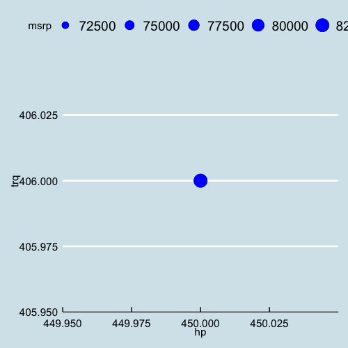

450  
@5800rpm

406  
@1400rpm

$70,900

S7

hatchback

7 Speed  
*Automatic*

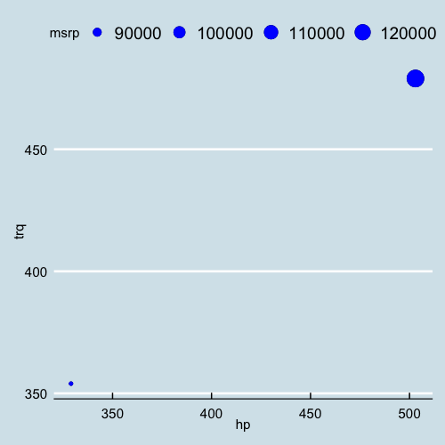

450  
@5800rpm

406  
@1400rpm

$82,900

Mercedes-Benz 🇩🇪

SL-Class

convertible

7 Speed  
*Automatic/Manual*

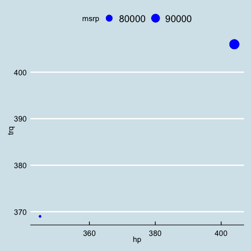

329  
@5250rpm

354  
@1600rpm

$85,050

AMG GT

coupe

7 Speed  
*Automatic*

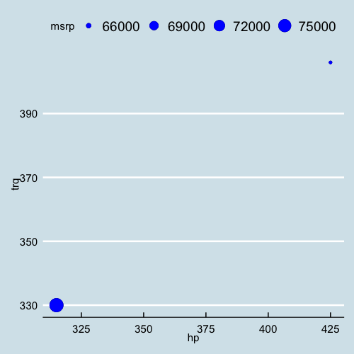

503  
@6250rpm

479  
@1750rpm

$129,900

Maserati 🇮🇹

Ghibli

sedan

8 Speed  
*Automatic/Manual*

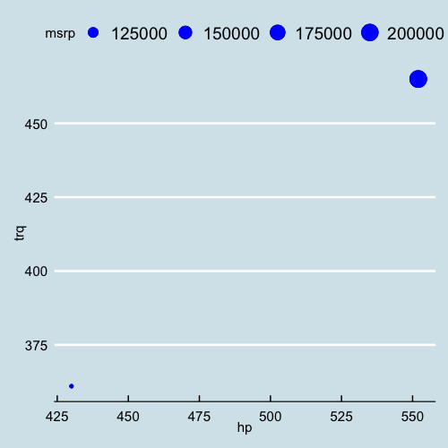

345  
@5250rpm

369  
@1750rpm

$70,600

Quattroporte

sedan

8 Speed  
*Automatic/Manual*

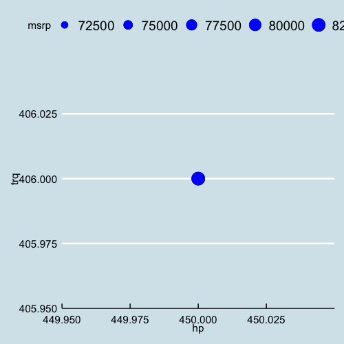

404  
@5500rpm

406  
@1500rpm

$99,900

BMW 🇩🇪

M4

coupe

6 Speed  
*Manual*

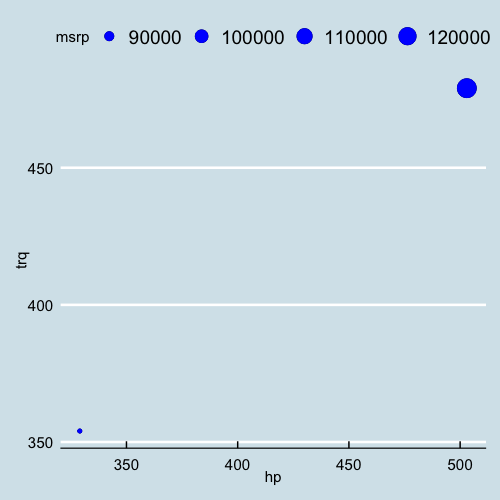

425  
@5500rpm

406  
@1850rpm

$65,700

6-Series

coupe

8 Speed  
*Automatic/Manual*

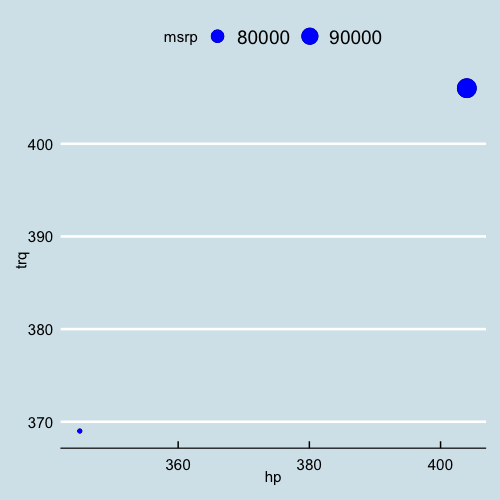

315  
@5800rpm

330  
@1400rpm

$77,300

Aston Martin 🇬🇧

Vantage

coupe

6 Speed  
*Manual*

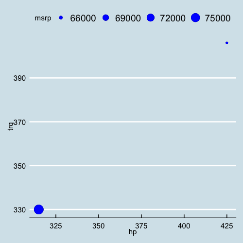

430  
@7300rpm

361  
@5000rpm

$103,300

Rapide S

sedan

8 Speed  
*Automatic/Manual*

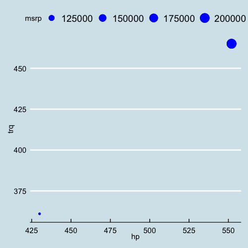

552  
@6650rpm

465  
@5500rpm

$205,300

Source: Various pages within the Edmonds website.

<sup>*1*</sup> All prices in U.S. dollars (USD).

## Refrences and go to Articles

- The mockup blog - https://themockup.blog/posts/2020-05-16-gt-a-grammer-of-tables/.
- 10 table rules in r - https://themockup.blog/posts/2020-09-04-10-table-rules-in-r/
- Exploring the gt package in r - https://towardsdatascience.com/exploring-the-gt-grammar-of-tables-package-in-r-7fff9d0b40cd
- Introduction to Creating gt Tables - https://gt.rstudio.com/articles/intro-creating-gt-tables.html
- Refrence Manual - https://cran.r-project.org/web/packages/gt/gt.pdf

## Next Steps

Congratulations! We have now successfully explored the gtcars dataset, we have 5 more inbuilt datasets to explore - sp500, pizzaplace, and exibble! Pick one of them and

- Create a basic gt table
- Add a title, subtitle
- Add Column Spanners
- Format Decimal place of the columns
- Add a footnote & source note
- Color, Color, Color!